# Concrete Stregth Prediction

```python
import warnings
warnings.filterwarnings('ignore')
import random
import pandas as pd
import numpy as np
import matplotlib.pyplot as plt
%matplotlib inline
plt.style.use('ggplot')
import seaborn as sns
from IPython.core.display import display, HTML
display(HTML("<style>.container { width:95% !important; }</style>"))

# Import Linear Regression machine learning library
from sklearn.linear_model import LinearRegression, Ridge, Lasso
from sklearn.model_selection import train_test_split
from sklearn.model_selection import KFold
from sklearn.model_selection import cross_val_score
from sklearn.model_selection import GridSearchCV
from sklearn.model_selection import RandomizedSearchCV
from sklearn.tree import DecisionTreeRegressor
from sklearn.ensemble import RandomForestRegressor
```

Cement (component 1) -- quantitative -- kg in a m3 mixture -- Input Variable

Blast Furnace Slag (component 2) -- quantitative -- kg in a m3 mixture -- Input Variable

Fly Ash (component 3) -- quantitative -- kg in a m3 mixture -- Input Variable

Water (component 4) -- quantitative -- kg in a m3 mixture -- Input Variable

Superplasticizer (component 5) -- quantitative -- kg in a m3 mixture -- Input Variable

Coarse Aggregate (component 6) -- quantitative -- kg in a m3 mixture -- Input Variable

Fine Aggregate (component 7) -- quantitative -- kg in a m3 mixture -- Input Variable

Age -- quantitative -- Day (1~365) -- Input Variable

Concrete compressive strength -- quantitative -- MPa -- Output Variable

```python
# importing data
df = pd.read_csv("concrete.csv")
df.head()      # used to see top 5 rows of the dataset
```

|  | cement | slag | ash | water | superplastic | coarseagg | fineagg | age | strength |
| --- | --- | --- | --- | --- | --- | --- | --- | --- | --- |
| 0 | 141.3 | 212.0 | 0.0 | 203.5 | 0.0 | 971.8 | 748.5 | 28 | 29.89 |
| 1 | 168.9 | 42.2 | 124.3 | 158.3 | 10.8 | 1080.8 | 796.2 | 14 | 23.51 |
| 2 | 250.0 | 0.0 | 95.7 | 187.4 | 5.5 | 956.9 | 861.2 | 28 | 29.22 |
| 3 | 266.0 | 114.0 | 0.0 | 228.0 | 0.0 | 932.0 | 670.0 | 28 | 45.85 |
| 4 | 154.8 | 183.4 | 0.0 | 193.3 | 9.1 | 1047.4 | 696.7 | 28 | 18.29 |

# 1. Univariate analysis (10 Marks)

```python
#five point analysis
df.describe().transpose()
```

|  | count | mean | std | min | 25% | 50% | 75% | max |
| --- | --- | --- | --- | --- | --- | --- | --- | --- |
| cement | 1030.0 | 281.167864 | 104.506364 | 102.00 | 192.375 | 272.900 | 350.000 | 540.0 |
| slag | 1030.0 | 73.895825 | 86.279342 | 0.00 | 0.000 | 22.000 | 142.950 | 359.4 |
| ash | 1030.0 | 54.188350 | 63.997004 | 0.00 | 0.000 | 0.000 | 118.300 | 200.1 |
| water | 1030.0 | 181.567282 | 21.354219 | 121.80 | 164.900 | 185.000 | 192.000 | 247.0 |
| superplastic | 1030.0 | 6.204660 | 5.973841 | 0.00 | 0.000 | 6.400 | 10.200 | 32.2 |
| coarseagg | 1030.0 | 972.918932 | 77.753954 | 801.00 | 932.000 | 968.000 | 1029.400 | 1145.0 |
| fineagg | 1030.0 | 773.580485 | 80.175980 | 594.00 | 730.950 | 779.500 | 824.000 | 992.6 |
| age | 1030.0 | 45.662136 | 63.169912 | 1.00 | 7.000 | 28.000 | 56.000 | 365.0 |
| strength | 1030.0 | 35.817961 | 16.705742 | 2.33 | 23.710 | 34.445 | 46.135 | 82.6 |

```python
#checking for datatypes
df.info()
```

```
<class 'pandas.core.frame.DataFrame'>
RangeIndex: 1030 entries, 0 to 1029
Data columns (total 9 columns):
 #   Column        Non-Null Count  Dtype
---  ------        --------------  -----
 0   cement        1030 non-null   float64
 1   slag          1030 non-null   float64
 2   ash           1030 non-null   float64
 3   water         1030 non-null   float64
 4   superplastic  1030 non-null   float64
 5   coarseagg     1030 non-null   float64
 6   fineagg       1030 non-null   float64
 7   age           1030 non-null   int64
 8   strength      1030 non-null   float64
dtypes: float64(8), int64(1)
memory usage: 72.5 KB
```

```python
#no of rows and columns
df.shape
```

```
(1030, 9)
```

```python
#checking for null values
df.isnull().values.any()
```

```
False
```

```python
#checking for any skewed values
df.skew()
```

```
cement          0.509481
slag            0.800717
ash             0.537354
water           0.074628
superplastic    0.907203
coarseagg      -0.040220
fineagg        -0.253010
age             3.269177
strength        0.416977
dtype: float64
```

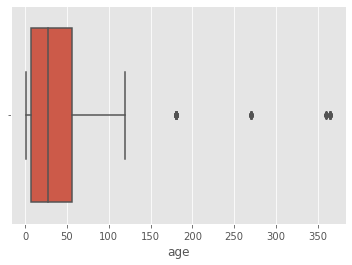

```python
#visualizing age skewness using a box plot
sns.boxplot(df['age'])
```

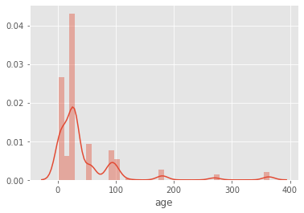

```python
sns.distplot(df['age'])
# Age value less than 365 is allowed since the age value in this can range (1~365)
```

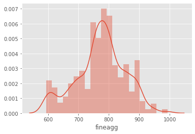

```python
sns.distplot(df['fineagg'])
```

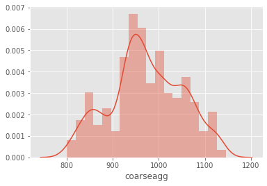

```python
sns.distplot(df['coarseagg'])
```

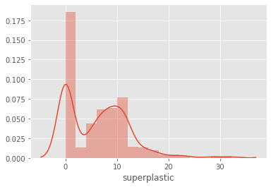

```python
sns.distplot(df['superplastic'])
```

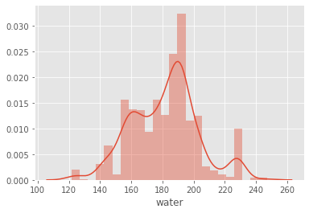

```python
sns.distplot(df['water'])
```

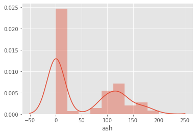

```python
sns.distplot(df['ash'])
```

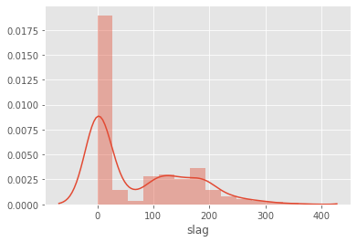

```python
sns.distplot(df['slag'])
```

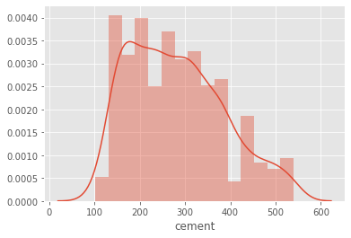

```python
sns.distplot(df['cement'])
```

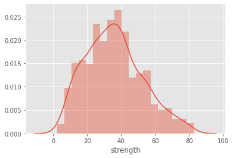

```python
sns.distplot(df['strength'], kde= True)
```

# 2.Bivariate Analysis (10 Marks)

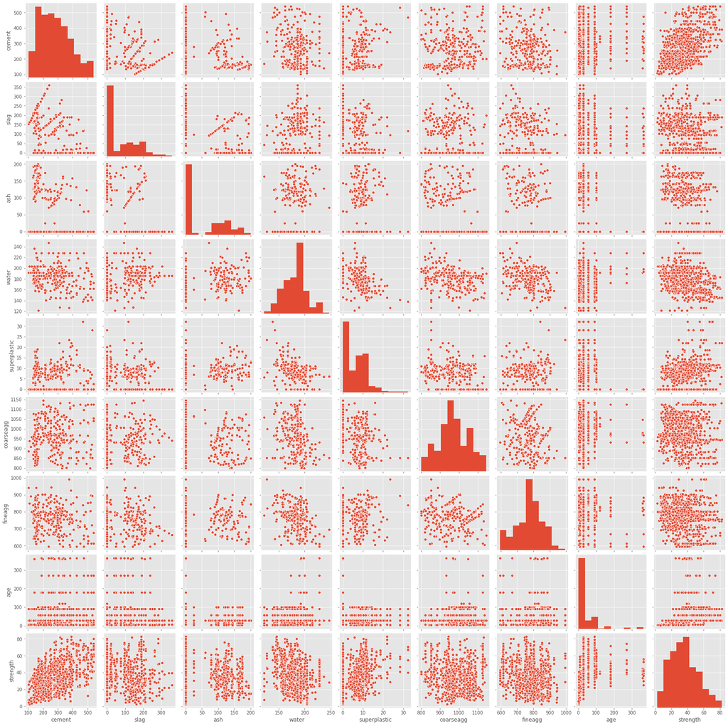

```python
sns.pairplot(df)
#From the pariplot as cement increases strength also increase
```

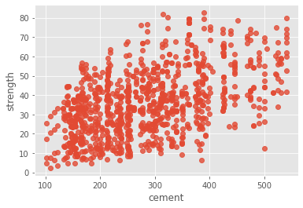

```python
# visualise area-price relationship
sns.regplot(x="cement", y="strength", data=df, fit_reg=False)
```

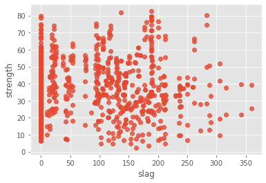

```python
sns.regplot(x="slag", y="strength", data=df, fit_reg=False)
```

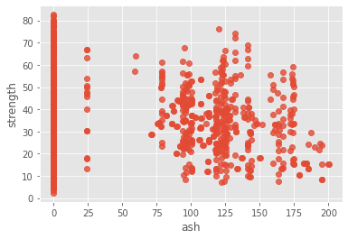

```python
sns.regplot(x="ash", y="strength", data=df, fit_reg=False)
```

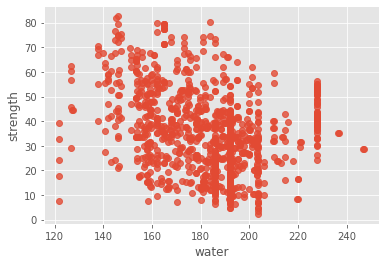

```python
sns.regplot(x="water", y="strength", data=df, fit_reg=False)
```

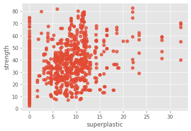

```python
sns.regplot(x="superplastic", y="strength", data=df, fit_reg=False)
```

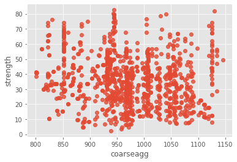

```python
sns.regplot(x="coarseagg", y="strength", data=df, fit_reg=False)
```

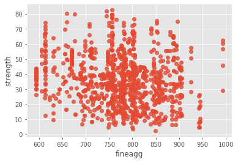

```python
sns.regplot(x="fineagg", y="strength", data=df, fit_reg=False)
```

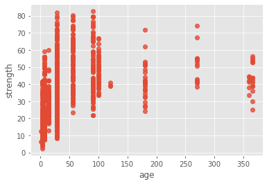

```python
sns.regplot(x="age", y="strength", data=df, fit_reg=False)
```